# DATA PROJECT

Angelica Gamboa and Gwendolyn Espinoza

2025-03-28

# INTRODUCTION

The data we gathered comes from the National Center for Health Statistics (NCHS), specifically the Leading Causes of Death in the United States dataset and reported crime incidents from the City of Chicago.The NCHS dataset provided us with information on the mortality statistics across various states throughout the years with the exception of murder.

To protect the privacy of the victims, the specific locations of the incidents are not identified, but rather addresses are shown at the block level. Several variables are included in this data such as Year, X113 cause name, cause name, state, deaths, and age adjusted death rate.

# QUESTIONS

1. What are the leading causes of death since 2001?
2. Which state had the most amount of deaths in the US?
3. What was the leading cause of death in California?
4. How has the cause of heart disease deaths changed over time?
5. How has the cause of cancer deaths changed over time?

# Unfiltered Data

```
## Rows: 10,868
## Columns: 6
## $ Year                    <int> 2017, 2017, 2017, 2017, 2017, 2017, 2017, 2017…
## $ X113.Cause.Name         <chr> "Accidents (unintentional injuries) (V01-X59,Y…
## $ Cause.Name              <chr> "Unintentional injuries", "Unintentional injur…
## $ State                   <chr> "United States", "Alabama", "Alaska", "Arizona…
## $ Deaths                  <int> 169936, 2703, 436, 4184, 1625, 13840, 3037, 20…
## $ Age.adjusted.Death.Rate <dbl> 49.4, 53.8, 63.7, 56.2, 51.8, 33.2, 53.6, 53.2…
```

# Data Key Terms

**Year**: Year in which the incident took place.  
**X113.Cause.Name**: The full, official name of the cause of death classified by the NCHS.  
**Cause.Name**: A broader label for the cause of death.  
**State**: The U.S. state where the data was collected.  
**Deaths**: The total number of deaths reported for a specific cause of death. **Age.adjusted.Death.Rate**: The death rate per 100,000 people, adjusted per age group for fair comparison.

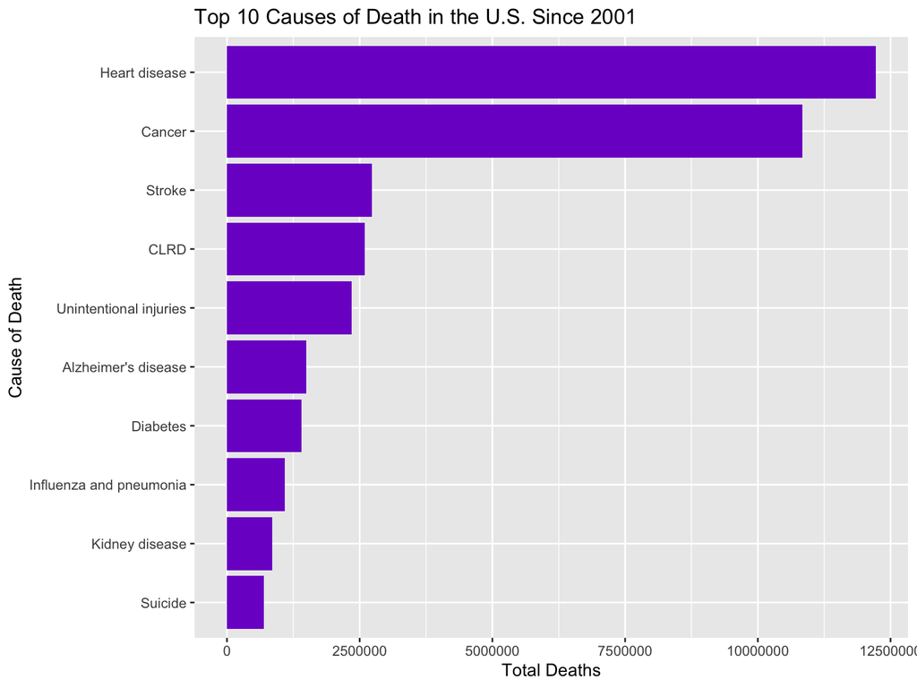

## **Total Deaths in Each State**

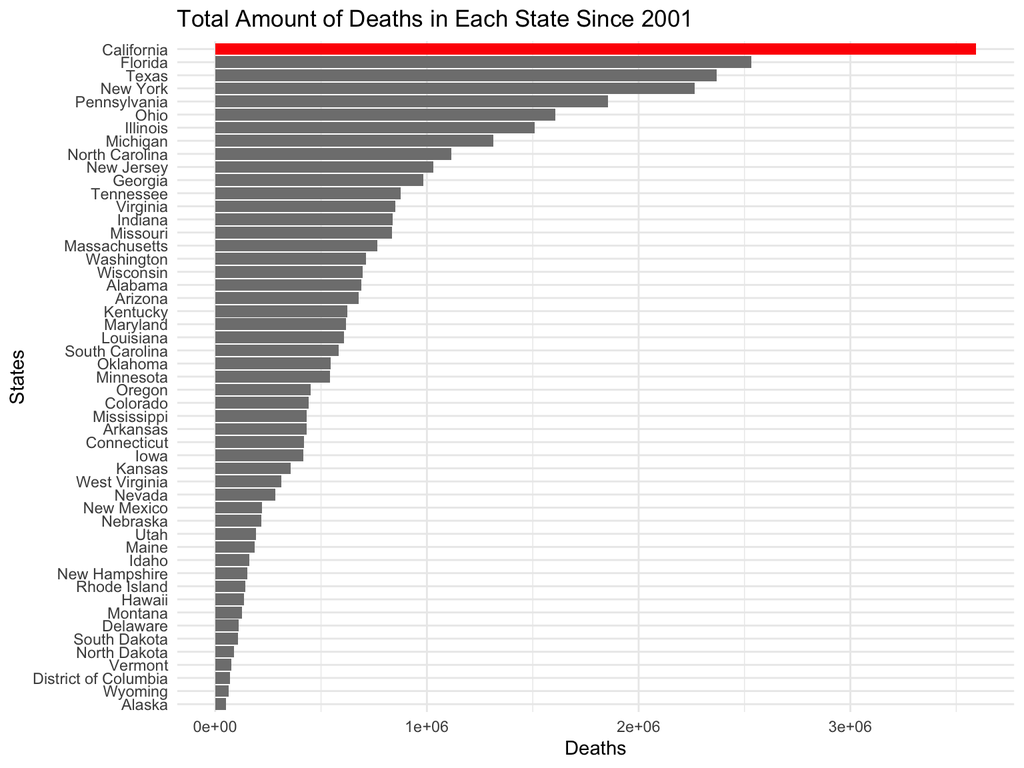

## **Leading Cause of Deaths in California**

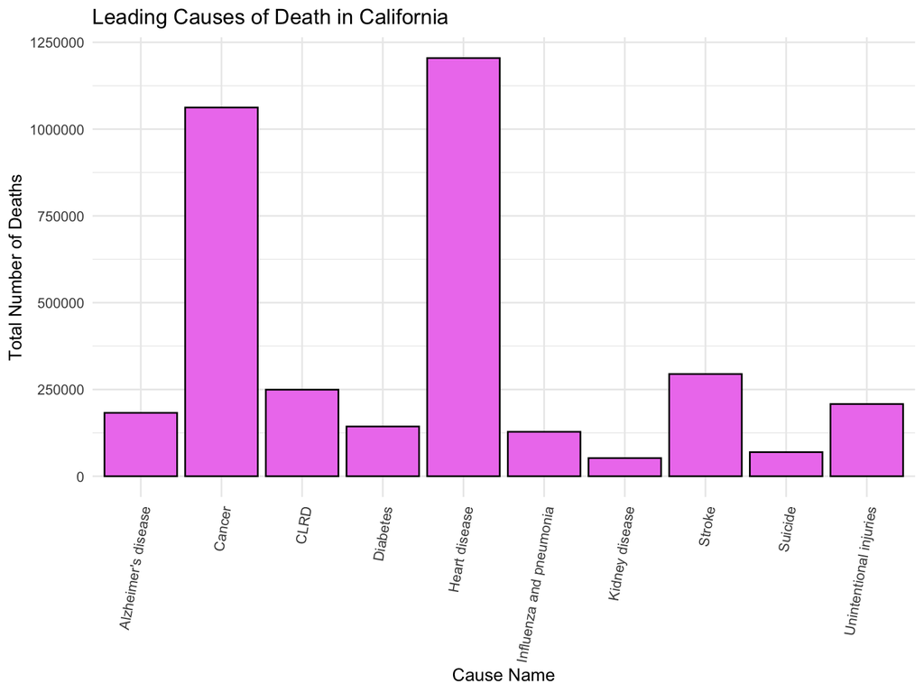

## **How has the number of heart disease deaths changed over time?**

```
## # A tibble: 19 × 2
##     Year Total_Heart_Deaths
##    <int>              <int>
##  1  1999            1450384
##  2  2000            1421520
##  3  2001            1400284
##  4  2002            1393894
##  5  2003            1370178
##  6  2004            1304972
##  7  2005            1304182
##  8  2006            1263272
##  9  2007            1232134
## 10  2008            1233656
## 11  2009            1198826
## 12  2010            1195378
## 13  2011            1193154
## 14  2012            1199422
## 15  2013            1222210
## 16  2014            1228696
## 17  2015            1267684
## 18  2016            1270520
## 19  2017            1294914
```

[figure not shown]

## **How has the number of cancer deaths changed over time?**

```
## # A tibble: 19 × 2
##     Year Total_Deaths
##    <int>        <int>
##  1  1999      1099676
##  2  2000      1106182
##  3  2001      1107536
##  4  2002      1114542
##  5  2003      1113804
##  6  2004      1107776
##  7  2005      1118624
##  8  2006      1119776
##  9  2007      1125750
## 10  2008      1130938
## 11  2009      1135256
## 12  2010      1149486
## 13  2011      1153382
## 14  2012      1165246
## 15  2013      1169762
## 16  2014      1183400
## 17  2015      1191860
## 18  2016      1196076
## 19  2017      1198216
```

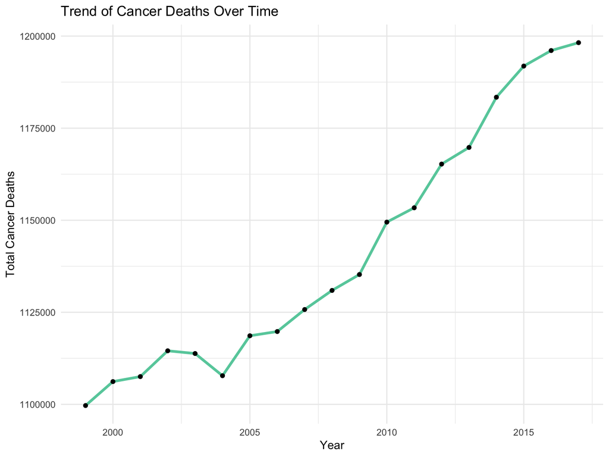

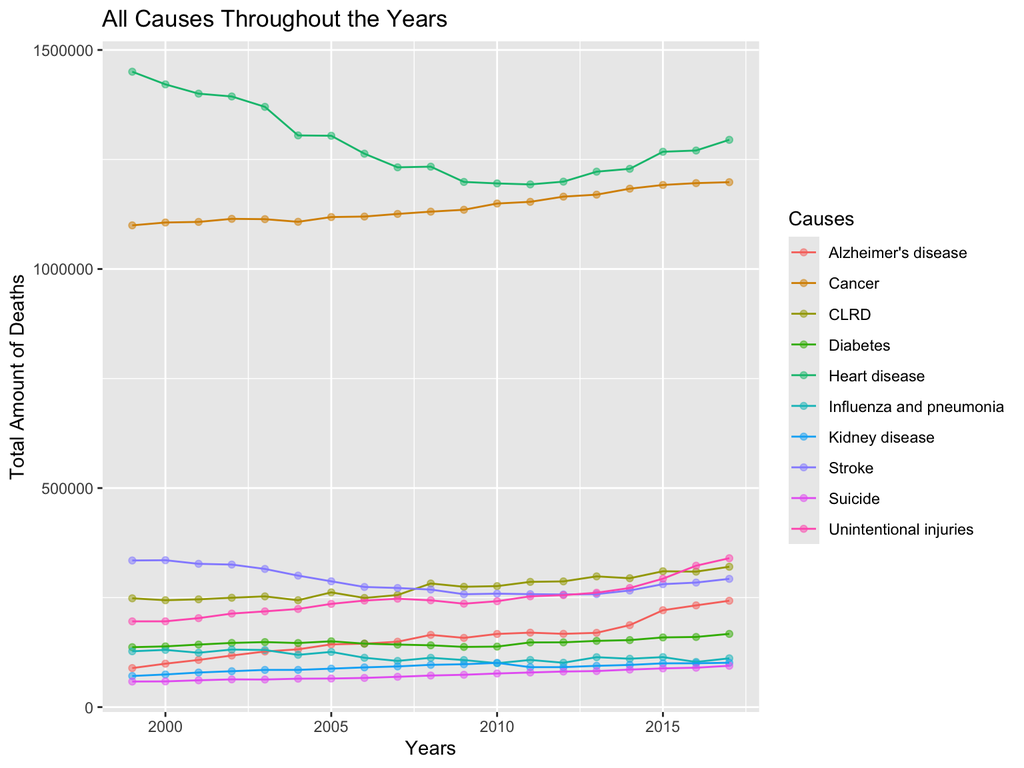

```r
#ALL DISEASES SEE HOW THEY ALL INCREAS / DECREASE THROUGHOUT THE YEARS
ALL <- data %>%
  select(Year, Cause.Name, Deaths) %>%
  filter(Cause.Name != 'All causes') %>%
  group_by(Cause.Name, Year) %>%
  summarize(TOT = sum(Deaths)) %>%
  ggplot(aes(x = Year, y = TOT, color = Cause.Name)) + geom_point(alpha = .5) + geom_line()+ labs(
   x = 'Years',
   y = 'Total Amount of Deaths',
   title = 'All Causes Throughout the Years',
   color = 'Causes'
    )
ALL
```

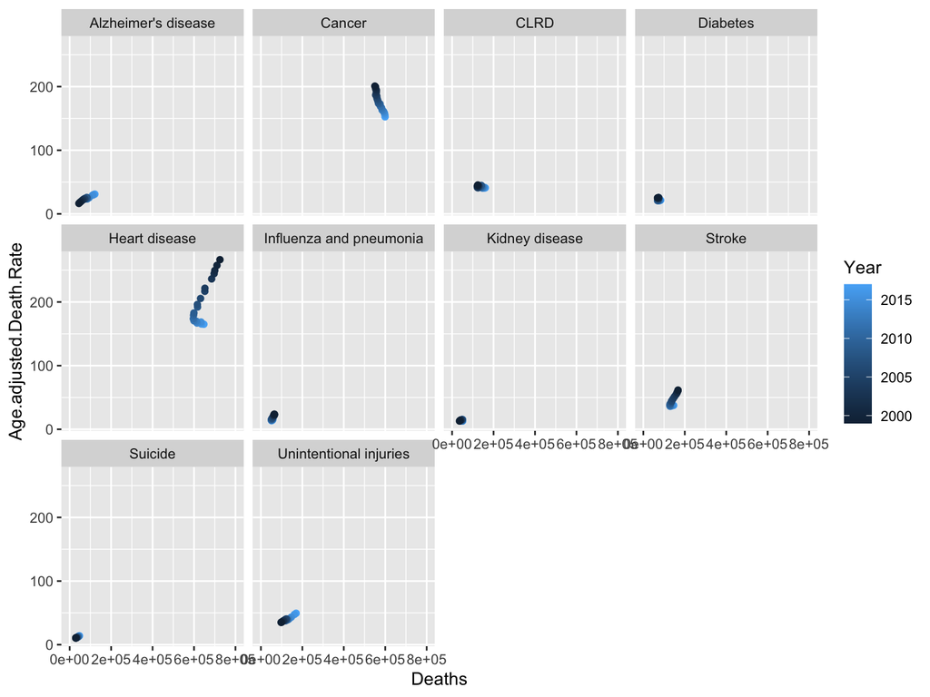

```r
#COMPARE DEATH AND AGE AJUSTED

COMPARISON <- data %>%
  select(Year, Age.adjusted.Death.Rate, Deaths,Cause.Name,State) %>%
  filter(Cause.Name != 'All causes', State == 'United States') %>%
  ggplot(aes(x = Deaths, y = Age.adjusted.Death.Rate, color = Year)) + geom_jitter() + facet_wrap(~Cause.Name) + coord_cartesian(xlim = c(0, 800000))

COMPARISON
```

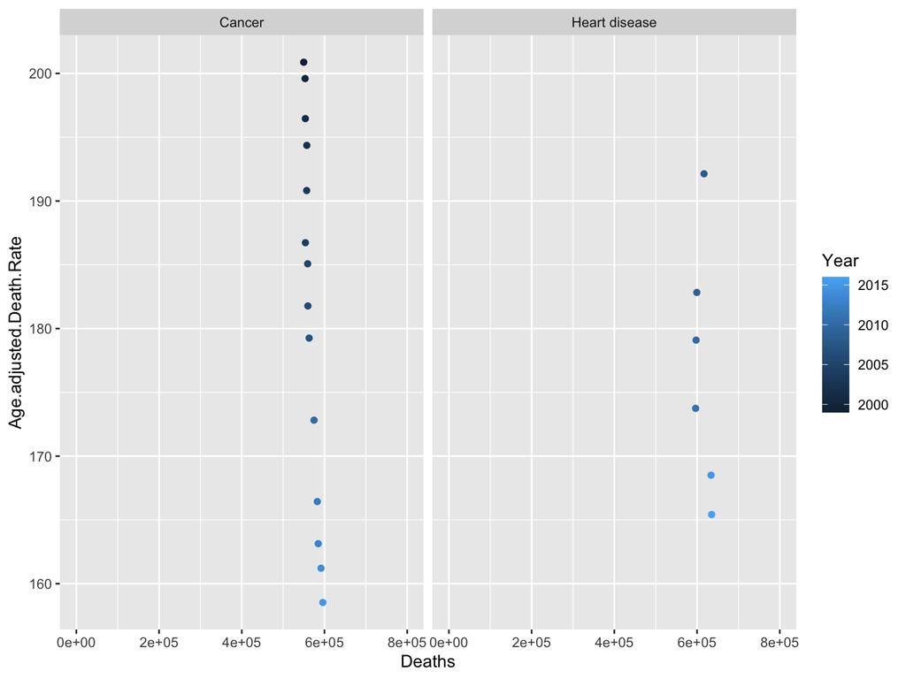

```r
COMPARISON.2 <- data %>%
  select(Year, Age.adjusted.Death.Rate, Deaths,Cause.Name,State) %>%
  filter(Cause.Name == c('Cancer','Heart disease'), State == 'United States') %>%
  ggplot(aes(x = Deaths, y = Age.adjusted.Death.Rate, color = Year)) + geom_jitter() + facet_wrap(~Cause.Name) + coord_cartesian(xlim = c(0, 800000))

COMPARISON.2
```